# Draft Prediction Interval

T. Bishop

2021-08-11

# Set Up

Start: August 2013

Load packages.

```r
library(geoR)
```

```r
library(lattice)
library(gstat)
library(moments)
library(ggplot2)
library(raster)
library(moments)
library(randomForest)
library(DescTools)
```

Set seed to have repeatable splits.

```r
set.seed(5)
```

# Process Data

## Import

```r
calib=read.table("C:\\Users\\bishop\\Dropbox (Sydney Uni)\\Research\\Projects\\Pedometrics2013\\Paper_Pred_Interval\\Data\\DecOdeh00_10.txt", header=TRUE, sep="\t", dec=".")
valid=read.table("C:\\Users\\bishop\\Dropbox (Sydney Uni)\\Research\\Projects\\Pedometrics2013\\Paper_Pred_Interval\\Data\\2010pcdata.txt", header=TRUE, sep="\t", dec=".")
```

## Fix names to match

```r
colnames(calib)[3]<-"clay"
colnames(valid)[4]<-"slu"
colnames(valid)[5]<-"lu"
colnames(valid)[6]<-"soil"
```

## Factors for soil, lu and slu

```r
calib$lu<-as.factor(calib$lu)
calib$slu<-as.factor(calib$slu)
calib$soil<-as.factor(calib$soil)

valid$lu<-as.factor(valid$lu)
valid$slu<-as.factor(valid$slu)
valid$soil<-as.factor(valid$soil)
```

# Exploratory Data Analysis

## Univariate

### Calibration set

```r
summary(calib$clay)
```

```
##    Min. 1st Qu.  Median    Mean 3rd Qu.    Max.
##    3.00   17.51   31.49   30.98   44.36   67.58
```

```r
length(calib$clay)
```

```
## [1] 97
```

```r
skewness(calib$clay)
```

```
## [1] 0.196189
```

```r
sqrt(var(calib$clay))
```

```
## [1] 16.48133
```

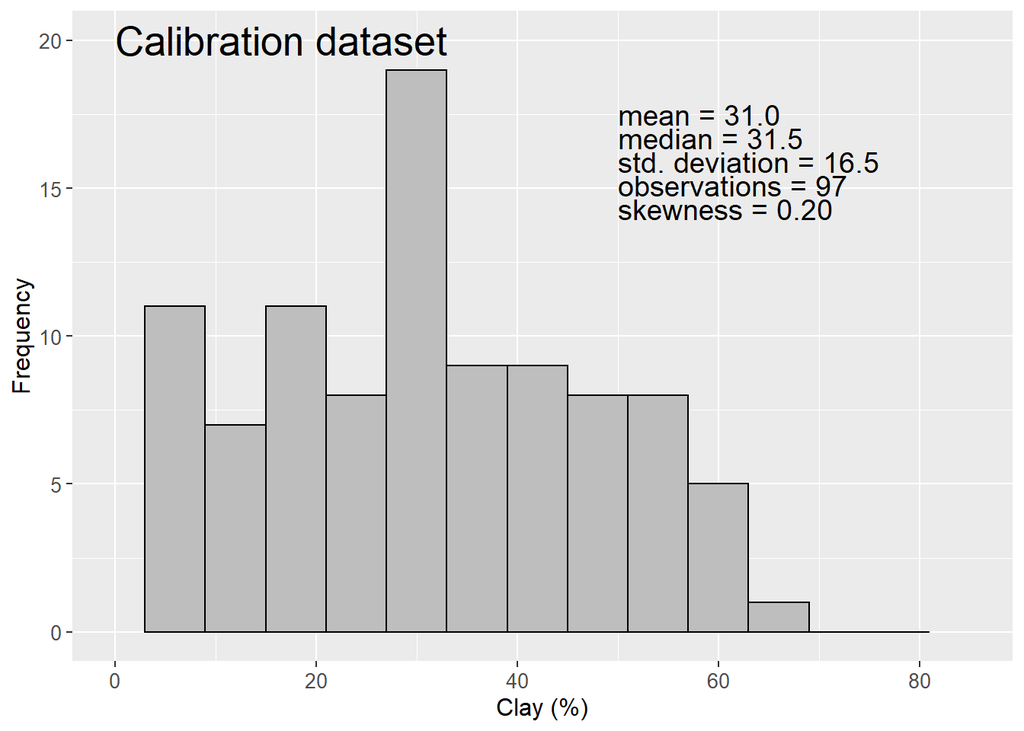

```r
sum.df<-data.frame (
  stats=c("mean = 31.0","median = 31.5", "std. deviation = 16.5", "observations = 97", "skewness = 0.20"),
  y=c(17.5, 16.7, 15.9, 15.1, 14.3))

#tiff('hist_calib.tiff')
ggplot(calib, aes(x=clay)) + geom_histogram(binwidth=6,colour='black',fill='grey')+
  xlab("Clay (%)") +
  ylab("Frequency") +
  theme(axis.title.y = element_text(size=20))+
  theme(axis.title.y = element_text(size=12),axis.text.y  = element_text(size=10))+
  xlim(0,85)+
  ylim(0,20)+
  theme(axis.title.x = element_text(size=12),axis.text.x  = element_text(size=10))+
  geom_text(data=sum.df,aes(x=50,y=y,label=stats),size=5, hjust=0)+
  annotate("text",x=0, y=20.0, label="Calibration dataset",size=7, hjust = 0)
```

```r
#   annotate("text",x=60, y=15, label="Median = 31.5",size=4)+
#   annotate("text",x=60, y=12, label="Observations = 97",size=4)
#dev.off()
```

### Validation set

```r
summary(valid$clay)
```

```
##    Min. 1st Qu.  Median    Mean 3rd Qu.    Max.
##    4.54   17.14   45.19   41.67   60.64   74.09
```

```r
length(valid$clay)
```

```
## [1] 44
```

```r
skewness(valid$clay)
```

```
## [1] -0.2680034
```

```r
sqrt(var(valid$clay))
```

```
## [1] 22.48818
```

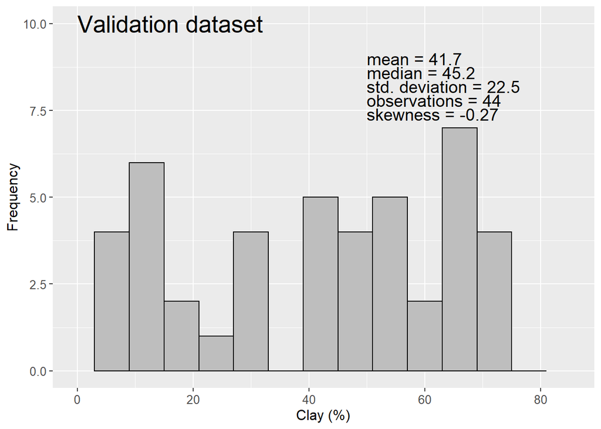

```r
sum.df<-data.frame (
  stats=c("mean = 41.7","median = 45.2", "std. deviation = 22.5", "observations = 44",  "skewness = -0.27"),
  y=c(9, 8.6, 8.2, 7.8, 7.4))

#tiff('hist_valid.tiff')
ggplot(valid, aes(x=clay)) + geom_histogram(binwidth=6,colour='black',fill='grey')+
  xlab("Clay (%)") +
  ylab("Frequency") +
  theme(axis.title.y = element_text(size=20))+
  theme(axis.title.y = element_text(size=12),axis.text.y  = element_text(size=10))+
  xlim(0,85)+
  ylim(0,10)+
  theme(axis.title.x = element_text(size=12),axis.text.x  = element_text(size=10))+
  geom_text(data=sum.df,aes(x=50,y=y,label=stats),size=5, hjust=0)+
  annotate("text",x=0, y=10.0, label="Validation dataset",size=7, hjust = 0)
```

```r
#   annotate("text",x=60, y=15, label="Median = 31.5",size=4)+
#   annotate("text",x=60, y=12, label="Observations = 97",size=4)
#dev.off()
```

## Bivariate

### Soil Classes

Re-code soil class

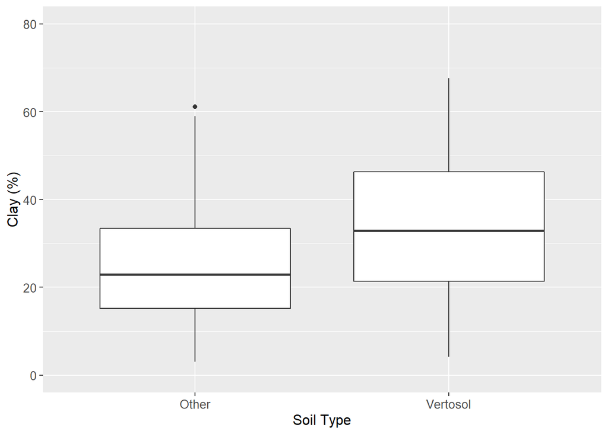

```r
calib$soil.type<-ifelse(calib$soil==1, "Vertosol", "Other")

#tiff('soil_clay.tiff')
p <- ggplot(calib, aes(x=soil.type, y=clay)) + geom_boxplot() +
  xlab("Soil Type") +
  ylab("Clay (%)")+
  theme(axis.title.y = element_text(size=20))+
  ylim(0,80)+
  theme(axis.title.y = element_text(size=12),axis.text.y  = element_text(size=10))+
  theme(axis.title.x = element_text(size=12),axis.text.x  = element_text(size=10))
p
```

```r
#dev.off()
```

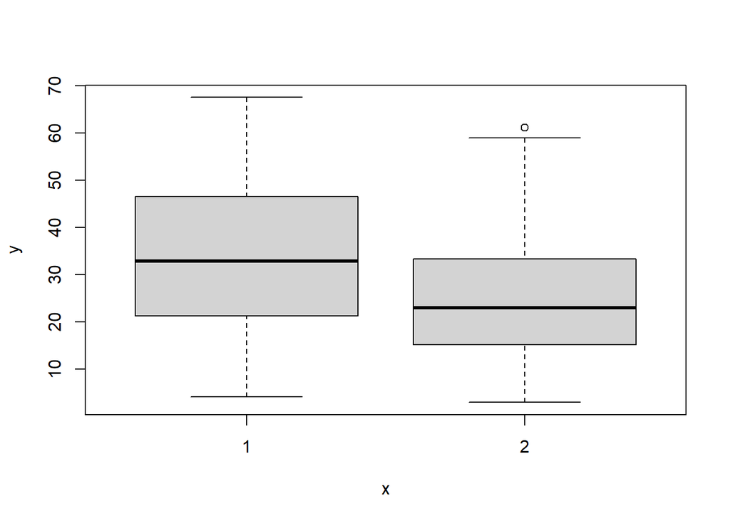

```r
plot(calib$soil,calib$clay)
```

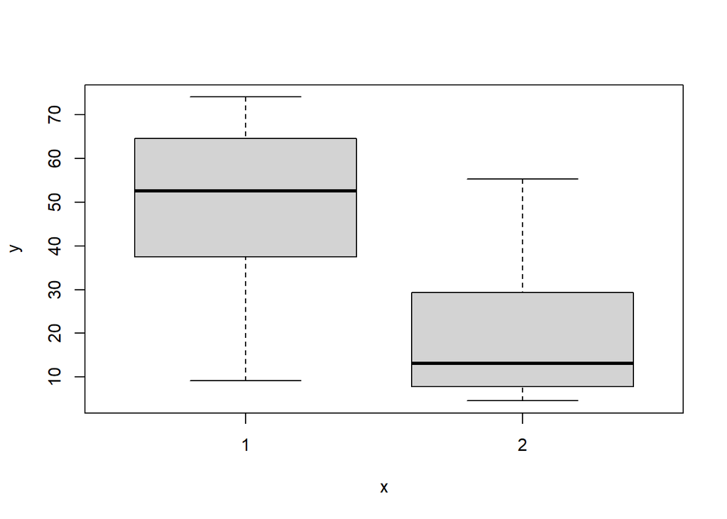

```r
plot(valid$soil,valid$clay)
```

```r
tapply(calib$clay,calib$soil,length)
```

```
##  1  2
## 56 41
```

Shows some difference - a candidate

### Land Use

COULD ADD label to figures (“text”,x=80, y=0, label=“a”,size=8)

Re-code land use

```r
calib$land.use<-ifelse(calib$lu==1, "Dryland cropping",
                 ifelse(calib$lu==2,"Forest",
                        ifelse(calib$lu==3, "Pasture","Irrigated")))

head(calib$lu)
```

```
## [1] 2 3 3 3 1 2
## Levels: 1 2 3 4
```

Cropping, Forest, Pasture, Irrigated

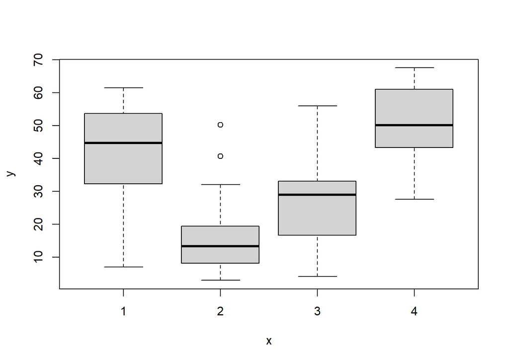

```r
plot(calib$lu,calib$clay)
```

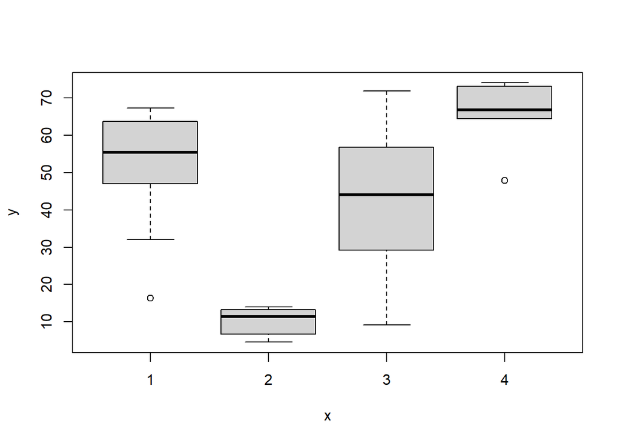

```r
plot(valid$lu,valid$clay)
```

```r
tapply(calib$clay,calib$lu,length)
```

```
##  1  2  3  4
## 31 17 44  5
```

```r
tapply(valid$clay,valid$lu,length)
```

```
##  1  2  3  4
## 14  9 16  5
```

Shows some difference - a candidate

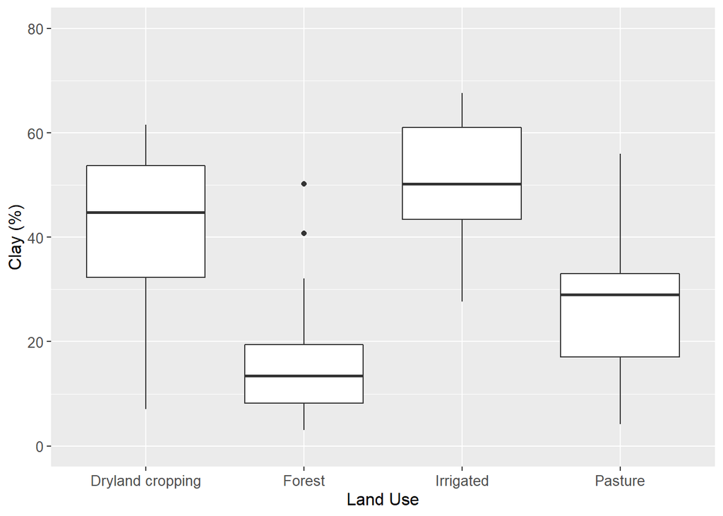

```r
#tiff('luse_clay.tiff')
p <- ggplot(calib, aes(x=land.use, y=clay)) + geom_boxplot() +
  xlab("Land Use") +
  ylab("Clay (%)")+
  theme(axis.title.y = element_text(size=20))+
  ylim(0,80)+
  theme(axis.title.y = element_text(size=12),axis.text.y  = element_text(size=10))+
  theme(axis.title.x = element_text(size=12),axis.text.x  = element_text(size=10))
p
```

```r
#dev.off()
```

### PCA

```r
skewness(calib[,7:12])
```

```
##         pc1         pc2         pc3         pc4         pc5         pc6
## -0.22323814 -1.27546102 -0.68739470  0.04674255  1.31956667  0.79521544
```

```r
cor(calib$clay,calib[,7:12])
```

```
##             pc1       pc2         pc3        pc4       pc5        pc6
## [1,] 0.07714535 0.2582924 -0.02229986 0.02979098 -0.211601 -0.5006531
```

```r
cor(calib$clay,calib[,7:12],method="spearman")
```

```
##            pc1       pc2         pc3       pc4        pc5        pc6
## [1,] 0.1123381 0.2255958 -0.03636543 0.0174957 -0.1381702 -0.4626875
```

No diff with spearman

# Linear Mixed Model

## Regression with OLS

Build prediction frame

```r
calib<-cbind(calib$clay,calib[,1:2],calib[,5:12])
colnames(calib)[1]<-"clay"
```

Fit model

```r
clay.lm<-lm(clay~soil+lu+pc1+pc2+pc3+pc4+pc5+pc6, data=calib)
summary(clay.lm)
```

```
##
## Call:
## lm(formula = clay ~ soil + lu + pc1 + pc2 + pc3 + pc4 + pc5 +
##     pc6, data = calib)
##
## Residuals:
##     Min      1Q  Median      3Q     Max
## -26.011  -7.403   0.015   7.917  31.660
##
## Coefficients:
##               Estimate Std. Error t value Pr(>|t|)
## (Intercept)  41.789721   2.985231  13.999  < 2e-16 ***
## soil2        -1.163723   3.186402  -0.365  0.71585
## lu2         -15.370266   4.859041  -3.163  0.00216 **
## lu3         -12.571371   3.050561  -4.121 8.65e-05 ***
## lu4          10.267105   6.555898   1.566  0.12100
## pc1           0.005153   0.011423   0.451  0.65305
## pc2           0.000493   0.035206   0.014  0.98886
## pc3           0.019261   0.054169   0.356  0.72303
## pc4           0.117793   0.066495   1.771  0.08003 .
## pc5          -0.190307   0.088031  -2.162  0.03341 *
## pc6          -0.373190   0.081590  -4.574 1.60e-05 ***
## ---
## Signif. codes:  0 '***' 0.001 '**' 0.01 '*' 0.05 '.' 0.1 ' ' 1
##
## Residual standard error: 12.11 on 86 degrees of freedom
## Multiple R-squared:  0.5165, Adjusted R-squared:  0.4603
## F-statistic: 9.186 on 10 and 86 DF,  p-value: 3.722e-10
```

Model shows some promise with adjusted r2 of 0.46.

Test model assumptions

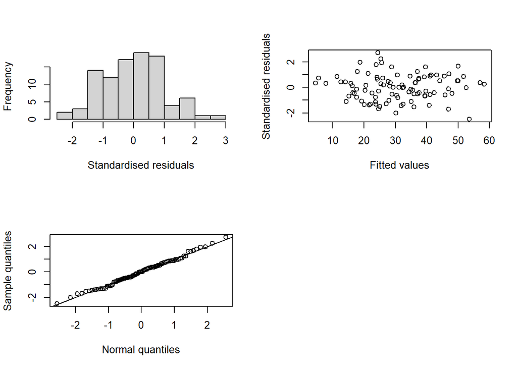

```r
par(mfrow=c(2,2))
hist(rstandard(clay.lm),xlab="Standardised residuals",ylab="Frequency",main=NULL)
#skewness(clay.lm$residuals)
plot(clay.lm$fitted.values,(rstandard(clay.lm)),xlab="Fitted values",ylab="Standardised residuals")
qqnorm(rstandard(clay.lm),main=NULL,xlab="Normal quantiles",ylab="Sample quantiles")
abline(0,1)
```

Assumptions met but lets check with Wally Plots.

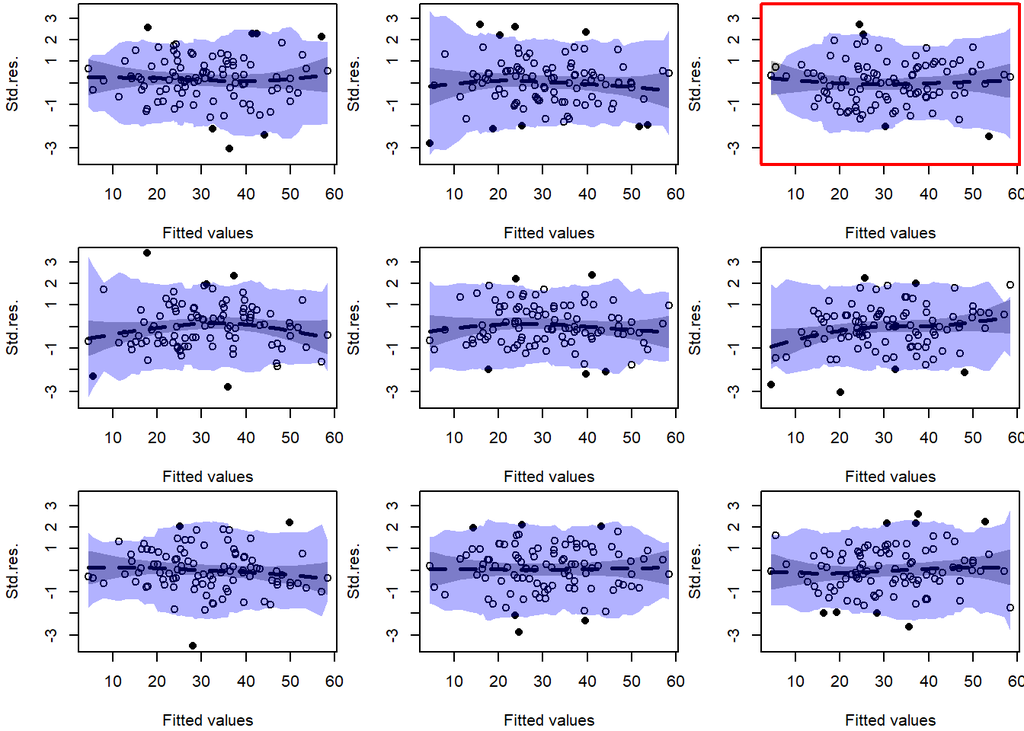

```
## Hit <Enter> to show the original plot.
```

```r
library(MESS)
wallyplot(clay.lm)
```

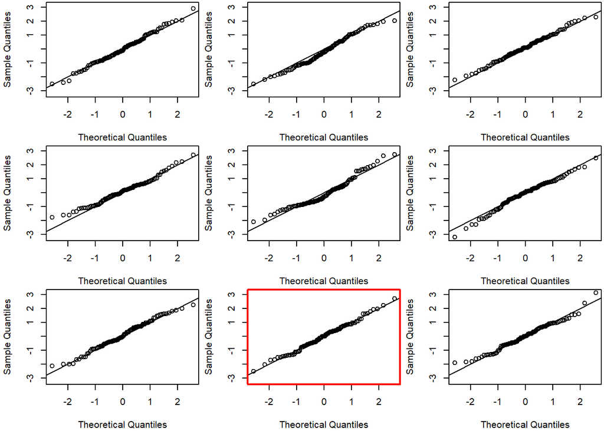

```
## Hit <Enter> to show the original plot.
```

```r
qqnorm.wally <- function(x, y, ...) { qqnorm(y, ...) ; abline(a=0, b=1) }
wallyplot(clay.lm, FUN=qqnorm.wally, main="")
```

## Fit Linear Mixed Model

Create GeoR object and include OLS residuals to examine spatial structure of these to see if kriging residuals has merit.

```r
calib<-cbind(calib,clay.lm$residuals)
head(calib)
```

```
##        clay      x       y lu soil     pc1    pc2    pc3   pc4    pc5   pc6
## 1 17.389109 786689 6598311  2    1  100.55 -14.96   2.51 19.91 -17.52 53.52
## 2 21.015332 787409 6598131  3    1   33.88  51.32 -20.66 -9.18 -10.52 49.77
## 3 34.648043 771389 6597771  3    2  129.27 -26.19  -3.79 54.69  12.90 17.58
## 4 17.681012 785789 6597231  3    2 -147.01  -1.22   5.67 26.31  -9.06 42.58
## 5  7.059629 784619 6597141  1    1  -29.47  53.02 -31.91 17.43   4.51 32.24
## 6 19.026212 785699 6596871  2    2    9.13  -1.07  18.69  2.39 -16.27 40.04
##   clay.lm$residuals
## 1          4.704236
## 2          9.647992
## 3          8.586754
## 4          1.342392
## 5        -23.152975
## 6          4.928668
```

```r
colnames(calib)[12] <- "residuals"
res <- as.geodata(calib,coords.col=2:3,data.col=12, covar.col=4:11)
res_var <- variog(res,option= "bin",messages = T,uvec=c(seq(0,50000,2000)))
```

```
## variog: computing omnidirectional variogram
```

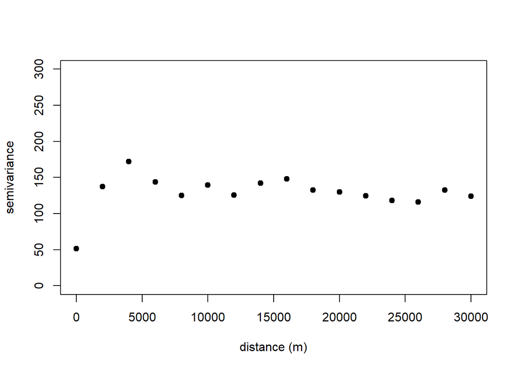

```r
plot(res_var, pch = 19, ylim=c(0,300),xlim=c(0,30000),col= "black", main="",xlab="distance (m)")
```

Residuals indicate short range spatail structure out to 5km so kriging of residuals shows promise. Now create new GeoR object where response is clay.

```r
gcalib <- as.geodata(calib,coords.col=2:3,data.col=1, covar.col=4:11)
summary(gcalib)
```

```
## Number of data points: 97
##
## Coordinates summary
##          x       y
## min 758699 6557541
## max 792089 6598311
##
## Distance summary
##        min        max
##   127.2792 52118.3154
##
## Data summary
##     Min.  1st Qu.   Median     Mean  3rd Qu.     Max.
##  3.00000 17.50569 31.49290 30.97979 44.36097 67.58417
##
## Covariates summary
##  lu     soil        pc1               pc2               pc3
##  1:31   1:56   Min.   :-211.95   Min.   :-140.44   Min.   :-89.140
##  2:17   2:41   1st Qu.:-118.43   1st Qu.:  -1.07   1st Qu.:-12.480
##  3:44          Median :   2.63   Median :  33.55   Median :  2.740
##  4: 5          Mean   : -10.04   Mean   :  19.48   Mean   :  1.241
##                3rd Qu.:  93.81   3rd Qu.:  52.73   3rd Qu.: 18.070
##                Max.   : 152.28   Max.   :  87.61   Max.   : 67.580
##       pc4               pc5               pc6
##  Min.   :-45.210   Min.   :-37.830   Min.   :-19.740
##  1st Qu.: -7.310   1st Qu.: -8.980   1st Qu.: -6.110
##  Median :  6.700   Median : -0.500   Median :  3.390
##  Mean   :  5.934   Mean   :  1.772   Mean   :  7.488
##  3rd Qu.: 19.380   3rd Qu.:  9.840   3rd Qu.: 18.880
##  Max.   : 77.400   Max.   : 73.890   Max.   : 53.520
```

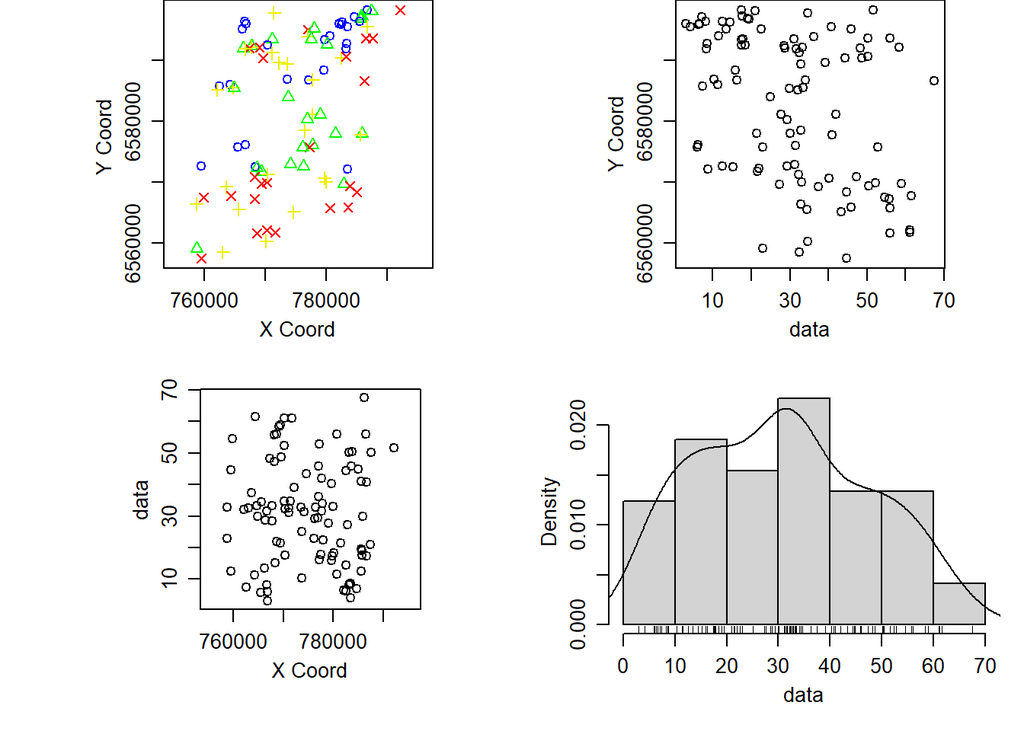

```r
plot(gcalib)
```

Define initial parameters for spatial correlation based on residual semivariogram. Use nugget as 1st lag semivariance. Have a few parameter combinations to find maximum likelihood and avoid local optima. First set is:

```r
init.par<-c(50,5000)
nug.par=50
lmm.exp <- likfit(gcalib, trend= ~soil+lu+pc1+pc2+pc3+pc4+pc5+pc6,
                  lambda=1,ini.cov.pars = init.par,fix.nugget = FALSE, nugget = nug.par,
                  lik.method = "REML", cov.model = "exp",limits = pars.limits(phi=c(0, 50000)))
```

[output not shown]

```r
lmm.exp$loglik
```

```
## [1] -331.4977
```

```r
lmm.exp$cov.pars
```

```
## [1]  124.964 5000.000
```

```r
lmm.exp$phi
```

```
## [1] 5000
```

```r
lmm.exp$nugget
```

```
## [1] 66.03681
```

Combination 2

```r
init.par<-c(25,5000)
nug.par=50
lmm.exp <- likfit(gcalib, trend= ~soil+lu+pc1+pc2+pc3+pc4+pc5+pc6,
                  lambda=1,ini.cov.pars = init.par,fix.nugget = FALSE, nugget = nug.par,
                  lik.method = "REML", cov.model = "exp",limits = pars.limits(phi=c(0, 50000)))
```

[output not shown]

```r
lmm.exp$loglik
```

```
## [1] -331.4977
```

```r
lmm.exp$cov.pars
```

```
## [1]  124.964 5000.000
```

```r
lmm.exp$phi
```

```
## [1] 5000
```

```r
lmm.exp$nugget
```

```
## [1] 66.03681
```

Combination 3

```r
init.par<-c(75,5000)
nug.par=50
lmm.exp <- likfit(gcalib, trend= ~soil+lu+pc1+pc2+pc3+pc4+pc5+pc6,
                  lambda=1,ini.cov.pars = init.par,fix.nugget = FALSE, nugget = nug.par,
                  lik.method = "REML", cov.model = "exp",limits = pars.limits(phi=c(0, 50000)))
```

[output not shown]

```r
lmm.exp$loglik
```

```
## [1] -331.4977
```

```r
lmm.exp$cov.pars
```

```
## [1]  124.9658 4999.9999
```

```r
lmm.exp$phi
```

```
## [1] 5000
```

```r
lmm.exp$nugget
```

```
## [1] 66.03611
```

Combination 4

```r
init.par<-c(50,10000)
nug.par=50
lmm.exp <- likfit(gcalib, trend= ~soil+lu+pc1+pc2+pc3+pc4+pc5+pc6,
                  lambda=1,ini.cov.pars = init.par,fix.nugget = FALSE, nugget = nug.par,
                  lik.method = "REML", cov.model = "exp",limits = pars.limits(phi=c(0, 50000)))
```

[output not shown]

```r
lmm.exp$loglik
```

```
## [1] -331.9863
```

```r
lmm.exp$cov.pars
```

```
## [1]   167.1508  9999.9999
```

```r
lmm.exp$phi
```

```
## [1] 10000
```

```r
lmm.exp$nugget
```

```
## [1] 75.47039
```

Combination 5

```r
init.par<-c(50,2000)
nug.par=50
lmm.exp <- likfit(gcalib, trend= ~soil+lu+pc1+pc2+pc3+pc4+pc5+pc6,
                  lambda=1,ini.cov.pars = init.par,fix.nugget = FALSE, nugget = nug.par,
                  lik.method = "REML", cov.model = "exp",limits = pars.limits(phi=c(0, 50000)))
```

[output not shown]

```r
lmm.exp$loglik
```

```
## [1] -330.9767
```

```r
lmm.exp$cov.pars
```

```
## [1]  133.1604 1999.9997
```

```r
lmm.exp$phi
```

```
## [1] 2000
```

```r
lmm.exp$nugget
```

```
## [1] 34.05802
```

```r
summary(lmm.exp)
```

```
## Summary of the parameter estimation
## -----------------------------------
## Estimation method: restricted maximum likelihood
##
## Parameters of the mean component (trend):
##    beta0    beta1    beta2    beta3    beta4    beta5    beta6    beta7
##  41.6203  -1.1644 -15.2160 -12.0620   1.9855   0.0027   0.0243   0.0486
##    beta8    beta9   beta10
##   0.0844  -0.2045  -0.3134
##
## Parameters of the spatial component:
##    correlation function: exponential
##       (estimated) variance parameter sigmasq (partial sill) =  133.2
##       (estimated) cor. fct. parameter phi (range parameter)  =  2000
##    anisotropy parameters:
##       (fixed) anisotropy angle = 0  ( 0 degrees )
##       (fixed) anisotropy ratio = 1
##
## Parameter of the error component:
##       (estimated) nugget =  34.06
##
## Transformation parameter:
##       (fixed) Box-Cox parameter = 1 (no transformation)
##
## Practical Range with cor=0.05 for asymptotic range: 5991.464
##
## Maximised Likelihood:
##    log.L n.params      AIC      BIC
##   "-331"     "14"    "690"    "726"
##
## non spatial model:
##    log.L n.params      AIC      BIC
## "-336.5"     "12"    "697"  "727.9"
##
## Call:
## likfit(geodata = gcalib, trend = ~soil + lu + pc1 + pc2 + pc3 +
##     pc4 + pc5 + pc6, ini.cov.pars = init.par, fix.nugget = FALSE,
##     nugget = nug.par, lambda = 1, cov.model = "exp", lik.method = "REML",
##     limits = pars.limits(phi = c(0, 50000)))
```

The best combination is 5 but it is marginal. The spatial model is best due to smaller AIC. We plot model over residual variogram to see fit.

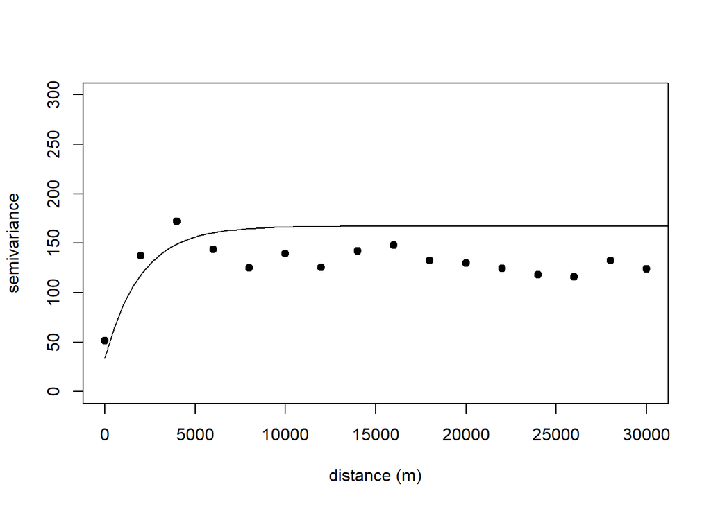

```r
plot(res_var, pch = 19, ylim=c(0,300),xlim=c(0,30000),col= "black", main="",xlab="distance (m)")
lines(lmm.exp)
```

### Variable Selection

Below is the function to perform Wald tests on the fixed effects.

```r
wald.test<-function(model.geostat){
fitmodel<-model.geostat
# get coefficients
coefficients <- fitmodel$beta
# get standard errors
se_error <- sqrt(diag(fitmodel$beta.var))
# get t values
t_value <- coefficients/se_error
# and probabilities
t_prob <- 2 * pt(-abs(t_value), df = (nrow(calib) -length (coefficients)))
# make pretty
coef_mat <- cbind(coefficients, se_error, t_value, t_prob)
colnames(coef_mat) <- c("Estimate", "Std.Err","t value", "Pr(>|t|)")
rownames(coef_mat) <- colnames(model.matrix(fitmodel$trend, gcalib))
return(printCoefmat(coef_mat))
}
```

We apply it to our model with all covariates.

```r
wald.test(lmm.exp)
```

```
##                Estimate     Std.Err t value  Pr(>|t|)
## (Intercept)  41.6202821   3.5000560 11.8913 < 2.2e-16 ***
## soil2        -1.1643958   3.0666872 -0.3797 0.7051102
## lu2         -15.2160236   4.6268106 -3.2887 0.0014596 **
## lu3         -12.0619755   3.1337561 -3.8490 0.0002273 ***
## lu4           1.9854994   6.5846526  0.3015 0.7637349
## pc1           0.0027041   0.0109260  0.2475 0.8051161
## pc2           0.0242948   0.0435014  0.5585 0.5779658
## pc3           0.0486193   0.0538497  0.9029 0.3691169
## pc4           0.0843787   0.0625910  1.3481 0.1811672
## pc5          -0.2045303   0.1063473 -1.9232 0.0577602 .
## pc6          -0.3133601   0.1225790 -2.5564 0.0123323 *
## ---
## Signif. codes:  0 '***' 0.001 '**' 0.01 '*' 0.05 '.' 0.1 ' ' 1
```

```r
init.par<-c(50,2000)
nug.par=50
lmm.exp <- likfit(gcalib, trend= ~soil+lu+pc1+pc3+pc4+pc5+pc6,
                  lambda=1,ini.cov.pars = init.par,fix.nugget = FALSE, nugget = nug.par,
                  lik.method = "REML", cov.model = "exp",limits = pars.limits(phi=c(0, 50000)))
```

[output not shown]

```r
summary(lmm.exp)
```

```
## Summary of the parameter estimation
## -----------------------------------
## Estimation method: restricted maximum likelihood
##
## Parameters of the mean component (trend):
##    beta0    beta1    beta2    beta3    beta4    beta5    beta6    beta7
##  42.6035  -1.7817 -16.0590 -12.2796   2.0392   0.0020   0.0500   0.0838
##    beta8    beta9
##  -0.2080  -0.3244
##
## Parameters of the spatial component:
##    correlation function: exponential
##       (estimated) variance parameter sigmasq (partial sill) =  129.7
##       (estimated) cor. fct. parameter phi (range parameter)  =  2000
##    anisotropy parameters:
##       (fixed) anisotropy angle = 0  ( 0 degrees )
##       (fixed) anisotropy ratio = 1
##
## Parameter of the error component:
##       (estimated) nugget =  35.18
##
## Transformation parameter:
##       (fixed) Box-Cox parameter = 1 (no transformation)
##
## Practical Range with cor=0.05 for asymptotic range: 5991.462
##
## Maximised Likelihood:
##    log.L n.params      AIC      BIC
## "-334.8"     "13"  "695.5"    "729"
##
## non spatial model:
##    log.L n.params      AIC      BIC
## "-339.9"     "11"  "701.8"  "730.1"
##
## Call:
## likfit(geodata = gcalib, trend = ~soil + lu + pc1 + pc3 + pc4 +
##     pc5 + pc6, ini.cov.pars = init.par, fix.nugget = FALSE, nugget = nug.par,
##     lambda = 1, cov.model = "exp", lik.method = "REML", limits = pars.limits(phi = c(0,
##         50000)))
```

```r
wald.test(lmm.exp)
```

```
##                Estimate     Std.Err t value  Pr(>|t|)
## (Intercept)  42.6034966   3.0007537 14.1976 < 2.2e-16 ***
## soil2        -1.7816749   2.8477619 -0.6256 0.5331886
## lu2         -16.0590249   4.3728171 -3.6725 0.0004141 ***
## lu3         -12.2795873   3.0940238 -3.9688 0.0001482 ***
## lu4           2.0391834   6.5514189  0.3113 0.7563489
## pc1           0.0019778   0.0108031  0.1831 0.8551617
## pc3           0.0499655   0.0535376  0.9333 0.3532597
## pc4           0.0838438   0.0623728  1.3442 0.1823672
## pc5          -0.2080335   0.1054780 -1.9723 0.0517524 .
## pc6          -0.3243735   0.1202623 -2.6972 0.0083960 **
## ---
## Signif. codes:  0 '***' 0.001 '**' 0.01 '*' 0.05 '.' 0.1 ' ' 1
```

We remove pc1.

```r
init.par<-c(50,2000)
nug.par=50
lmm.exp <- likfit(gcalib, trend= ~soil+lu+pc3+pc4+pc5+pc6,
                  lambda=1,ini.cov.pars = init.par,fix.nugget = FALSE, nugget = nug.par,
                  lik.method = "REML", cov.model = "exp",limits = pars.limits(phi=c(0, 50000)))
```

[output not shown]

```r
summary(lmm.exp)
```

```
## Summary of the parameter estimation
## -----------------------------------
## Estimation method: restricted maximum likelihood
##
## Parameters of the mean component (trend):
##    beta0    beta1    beta2    beta3    beta4    beta5    beta6    beta7
##  42.6649  -1.8390 -16.1156 -12.3968   1.7953   0.0499   0.0858  -0.2108
##    beta8
##  -0.3208
##
## Parameters of the spatial component:
##    correlation function: exponential
##       (estimated) variance parameter sigmasq (partial sill) =  128.2
##       (estimated) cor. fct. parameter phi (range parameter)  =  2000
##    anisotropy parameters:
##       (fixed) anisotropy angle = 0  ( 0 degrees )
##       (fixed) anisotropy ratio = 1
##
## Parameter of the error component:
##       (estimated) nugget =  34.86
##
## Transformation parameter:
##       (fixed) Box-Cox parameter = 1 (no transformation)
##
## Practical Range with cor=0.05 for asymptotic range: 5991.463
##
## Maximised Likelihood:
##    log.L n.params      AIC      BIC
## "-338.1"     "12"  "700.3"  "731.2"
##
## non spatial model:
##    log.L n.params      AIC      BIC
## "-343.4"     "10"  "706.8"  "732.6"
##
## Call:
## likfit(geodata = gcalib, trend = ~soil + lu + pc3 + pc4 + pc5 +
##     pc6, ini.cov.pars = init.par, fix.nugget = FALSE, nugget = nug.par,
##     lambda = 1, cov.model = "exp", lik.method = "REML", limits = pars.limits(phi = c(0,
##         50000)))
```

```r
wald.test(lmm.exp)
```

```
##               Estimate    Std.Err t value  Pr(>|t|)
## (Intercept)  42.664931   2.964992 14.3896 < 2.2e-16 ***
## soil2        -1.839014   2.814849 -0.6533 0.5152496
## lu2         -16.115604   4.338414 -3.7146 0.0003567 ***
## lu3         -12.396831   3.010245 -4.1182 8.596e-05 ***
## lu4           1.795312   6.374423  0.2816 0.7788784
## pc3           0.049919   0.053241  0.9376 0.3510172
## pc4           0.085801   0.061115  1.4039 0.1638559
## pc5          -0.210840   0.103776 -2.0317 0.0452025 *
## pc6          -0.320813   0.117967 -2.7195 0.0078765 **
## ---
## Signif. codes:  0 '***' 0.001 '**' 0.01 '*' 0.05 '.' 0.1 ' ' 1
```

We remove soil.

```r
init.par<-c(50,2000)
nug.par=50
lmm.exp <- likfit(gcalib, trend= ~lu+pc3+pc4+pc5+pc6,
                  lambda=1,ini.cov.pars = init.par,fix.nugget = FALSE, nugget = nug.par,
                  lik.method = "REML", cov.model = "exp",limits = pars.limits(phi=c(0, 50000)))
```

[output not shown]

```r
summary(lmm.exp)
```

```
## Summary of the parameter estimation
## -----------------------------------
## Estimation method: restricted maximum likelihood
##
## Parameters of the mean component (trend):
##    beta0    beta1    beta2    beta3    beta4    beta5    beta6    beta7
##  42.0956 -16.5001 -12.5469   2.1400   0.0467   0.0780  -0.2062  -0.3345
##
## Parameters of the spatial component:
##    correlation function: exponential
##       (estimated) variance parameter sigmasq (partial sill) =  126.8
##       (estimated) cor. fct. parameter phi (range parameter)  =  2000
##    anisotropy parameters:
##       (fixed) anisotropy angle = 0  ( 0 degrees )
##       (fixed) anisotropy ratio = 1
##
## Parameter of the error component:
##       (estimated) nugget =  34.96
##
## Transformation parameter:
##       (fixed) Box-Cox parameter = 1 (no transformation)
##
## Practical Range with cor=0.05 for asymptotic range: 5991.463
##
## Maximised Likelihood:
##    log.L n.params      AIC      BIC
## "-341.8"     "11"  "705.6"  "733.9"
##
## non spatial model:
##    log.L n.params      AIC      BIC
## "-346.9"      "9"  "711.9"  "735.1"
##
## Call:
## likfit(geodata = gcalib, trend = ~lu + pc3 + pc4 + pc5 + pc6,
##     ini.cov.pars = init.par, fix.nugget = FALSE, nugget = nug.par,
##     lambda = 1, cov.model = "exp", lik.method = "REML", limits = pars.limits(phi = c(0,
##         50000)))
```

```r
wald.test(lmm.exp)
```

```
##               Estimate    Std.Err t value  Pr(>|t|)
## (Intercept)  42.095593   2.822272 14.9155 < 2.2e-16 ***
## lu2         -16.500108   4.286563 -3.8493 0.0002227 ***
## lu3         -12.546873   2.991100 -4.1947 6.443e-05 ***
## lu4           2.140022   6.333012  0.3379 0.7362228
## pc3           0.046667   0.052838  0.8832 0.3795033
## pc4           0.077965   0.059741  1.3051 0.1952358
## pc5          -0.206186   0.103129 -1.9993 0.0486269 *
## pc6          -0.334480   0.115668 -2.8917 0.0048146 **
## ---
## Signif. codes:  0 '***' 0.001 '**' 0.01 '*' 0.05 '.' 0.1 ' ' 1
```

We remove pc3.

```r
init.par<-c(50,2000)
nug.par=50
lmm.exp <- likfit(gcalib, trend= ~lu+pc4+pc5+pc6,
                  lambda=1,ini.cov.pars = init.par,fix.nugget = FALSE, nugget = nug.par,
                  lik.method = "REML", cov.model = "exp",limits = pars.limits(phi=c(0, 50000)))
```

[output not shown]

```r
summary(lmm.exp)
```

```
## Summary of the parameter estimation
## -----------------------------------
## Estimation method: restricted maximum likelihood
##
## Parameters of the mean component (trend):
##    beta0    beta1    beta2    beta3    beta4    beta5    beta6
##  41.7830 -15.2379 -12.2916   3.1058   0.0868  -0.2351  -0.3506
##
## Parameters of the spatial component:
##    correlation function: exponential
##       (estimated) variance parameter sigmasq (partial sill) =  123
##       (estimated) cor. fct. parameter phi (range parameter)  =  2000
##    anisotropy parameters:
##       (fixed) anisotropy angle = 0  ( 0 degrees )
##       (fixed) anisotropy ratio = 1
##
## Parameter of the error component:
##       (estimated) nugget =  36.88
##
## Transformation parameter:
##       (fixed) Box-Cox parameter = 1 (no transformation)
##
## Practical Range with cor=0.05 for asymptotic range: 5991.463
##
## Maximised Likelihood:
##    log.L n.params      AIC      BIC
## "-345.6"     "10"  "711.2"  "736.9"
##
## non spatial model:
##    log.L n.params      AIC      BIC
## "-350.4"      "8"  "716.8"  "737.4"
##
## Call:
## likfit(geodata = gcalib, trend = ~lu + pc4 + pc5 + pc6, ini.cov.pars = init.par,
##     fix.nugget = FALSE, nugget = nug.par, lambda = 1, cov.model = "exp",
##     lik.method = "REML", limits = pars.limits(phi = c(0, 50000)))
```

```r
wald.test(lmm.exp)
```

```
##               Estimate    Std.Err t value  Pr(>|t|)
## (Intercept)  41.782993   2.780232 15.0286 < 2.2e-16 ***
## lu2         -15.237949   4.025517 -3.7853 0.0002764 ***
## lu3         -12.291614   2.969072 -4.1399 7.815e-05 ***
## lu4           3.105759   6.243356  0.4975 0.6200848
## pc4           0.086784   0.058893  1.4736 0.1440851
## pc5          -0.235089   0.097316 -2.4157 0.0177244 *
## pc6          -0.350595   0.113597 -3.0863 0.0026932 **
## ---
## Signif. codes:  0 '***' 0.001 '**' 0.01 '*' 0.05 '.' 0.1 ' ' 1
```

We remove pc4.

```r
init.par<-c(50,2000)
nug.par=50
lmm.exp <- likfit(gcalib, trend= ~lu+pc5+pc6,
                  lambda=1,ini.cov.pars = init.par,fix.nugget = FALSE, nugget = nug.par,
                  lik.method = "REML", cov.model = "exp",limits = pars.limits(phi=c(0, 50000)))
```

[output not shown]

```r
summary(lmm.exp)
```

```
## Summary of the parameter estimation
## -----------------------------------
## Estimation method: restricted maximum likelihood
##
## Parameters of the mean component (trend):
##    beta0    beta1    beta2    beta3    beta4    beta5
##  42.3623 -15.7844 -11.9678   0.0120  -0.2058  -0.3709
##
## Parameters of the spatial component:
##    correlation function: exponential
##       (estimated) variance parameter sigmasq (partial sill) =  126.7
##       (estimated) cor. fct. parameter phi (range parameter)  =  2000
##    anisotropy parameters:
##       (fixed) anisotropy angle = 0  ( 0 degrees )
##       (fixed) anisotropy ratio = 1
##
## Parameter of the error component:
##       (estimated) nugget =  36.12
##
## Transformation parameter:
##       (fixed) Box-Cox parameter = 1 (no transformation)
##
## Practical Range with cor=0.05 for asymptotic range: 5991.464
##
## Maximised Likelihood:
##    log.L n.params      AIC      BIC
##   "-350"      "9"    "718"  "741.2"
##
## non spatial model:
##    log.L n.params      AIC      BIC
## "-355.7"      "7"  "725.3"  "743.4"
##
## Call:
## likfit(geodata = gcalib, trend = ~lu + pc5 + pc6, ini.cov.pars = init.par,
##     fix.nugget = FALSE, nugget = nug.par, lambda = 1, cov.model = "exp",
##     lik.method = "REML", limits = pars.limits(phi = c(0, 50000)))
```

```r
wald.test(lmm.exp)
```

```
##               Estimate    Std.Err t value  Pr(>|t|)
## (Intercept)  42.362330   2.779932 15.2386 < 2.2e-16 ***
## lu2         -15.784372   4.032581 -3.9142 0.0001749 ***
## lu3         -11.967756   2.982349 -4.0129 0.0001230 ***
## lu4           0.011964   5.943230  0.0020 0.9983982
## pc5          -0.205845   0.096053 -2.1430 0.0347778 *
## pc6          -0.370943   0.113824 -3.2589 0.0015734 **
## ---
## Signif. codes:  0 '***' 0.001 '**' 0.01 '*' 0.05 '.' 0.1 ' ' 1
```

We now have our final model with land use and pc5 and pc6.

NOTE - likfit function not sensitive to range parameter - not sure if dataset specific or issue with library. Kate or Liana data?

## Model Testing

Now we perform cross-validation to assess the model in terms of its predictions - point and interval estimates.

First we do without re-fitting the model for each split.

```r
#xv.REML <- xvalid(gcalib, model = lmm.exp, reestimate=TRUE)
xv.REML <- xvalid(gcalib, model = lmm.exp)
```

[output not shown]

We test how well the prediction variance matches the errors.

```r
mean(xv.REML$std.error^2)
```

```
## [1] 1.033696
```

```r
median(xv.REML$std.error^2)
```

```
## [1] 0.5550591
```

We test the bias and accuracy and LCC.

```r
mean(xv.REML$error)
```

```
## [1] -0.0493863
```

```r
sqrt(mean(xv.REML$error^2))
```

```
## [1] 11.50238
```

```r
lcc<-CCC(xv.REML$data,xv.REML$predicted)
lcc$rho.c
```

```
##         est    lwr.ci    upr.ci
## 1 0.6900762 0.5786189 0.7762314
```

Now do by re-fitting model parameters at each plit.

```r
xv.REML2 <- xvalid(gcalib, model = lmm.exp, reestimate=TRUE,messages="F")
```

[output not shown]

[output cut: 332 more lines]

[output not shown]

We test how well the prediction variance matches the errors.

```r
mean(xv.REML2$std.error^2)
```

```
## [1] 1.106382
```

```r
median(xv.REML2$std.error^2)
```

```
## [1] 0.5316799
```

We test the bias and accuracy and LCC.

```r
mean(xv.REML2$error)
```

```
## [1] -0.06145626
```

```r
sqrt(mean(xv.REML2$error^2))
```

```
## [1] 11.68036
```

```r
lcc<-CCC(xv.REML2$data,xv.REML2$predicted)
lcc$rho.c
```

```
##         est    lwr.ci   upr.ci
## 1 0.6805448 0.5662737 0.769147
```

Let compare predictions, prediction variance and standardised error using both CV approaches.

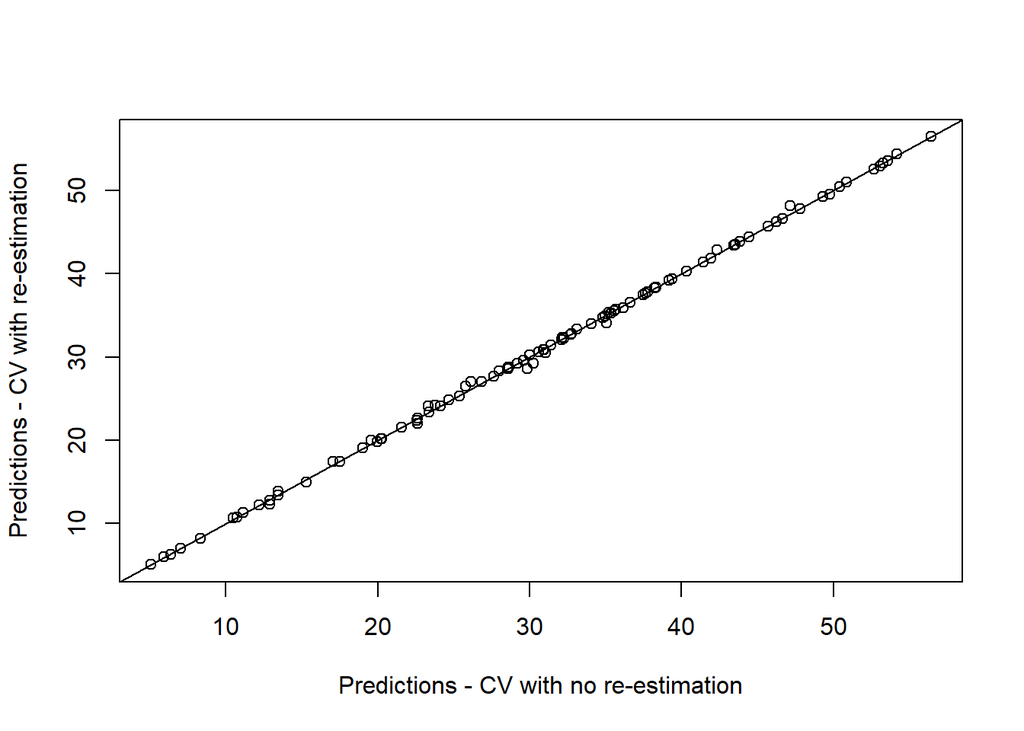

```r
plot(xv.REML$predicted,xv.REML2$predicted, xlab ="Predictions - CV with no re-estimation", ylab ="Predictions - CV with re-estimation")
abline(0,1)
```